# topictry

2023-12-25

## Overview of Topic Modeling

We first lay out a basic topic model without any accounting for time.

In this model, we have a number of people, M.

For each person, they have a distribution of topic responsibility on K topics, $\theta_{i}$.

This topic distribution will be sparsely simulated so individuals are loaded on a minimal number of topics using a random dirichelt with $\alpha$ = 0.1.

For each topic, there is a distribution on diseases. There are a total of V disease. This parameter $\phi$, over diseases, is simulated alos according to a sparse dirichlet.

```r
library(rBeta2009)
```

```r
library(ggplot2)
library(reshape2)
library(splines)
# number of people
M=100

# number of topics
K=5

## number of diagnoses per patient, mean of 10 diagnoses per patient
Nd=rpois(M,lambda = 10)

## total numer of diagnoses
N=sum(Nd)

# number of disease total
V=20
```

[output not shown]

[output not shown]

Show the distirbtuion of theta and phi

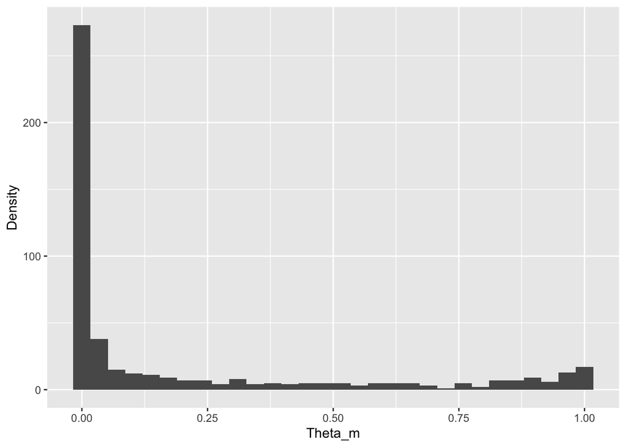

```r
ggplot(data = melt(theta),aes(x=value))+geom_histogram()+labs(x="Theta_m",y="Density")
```

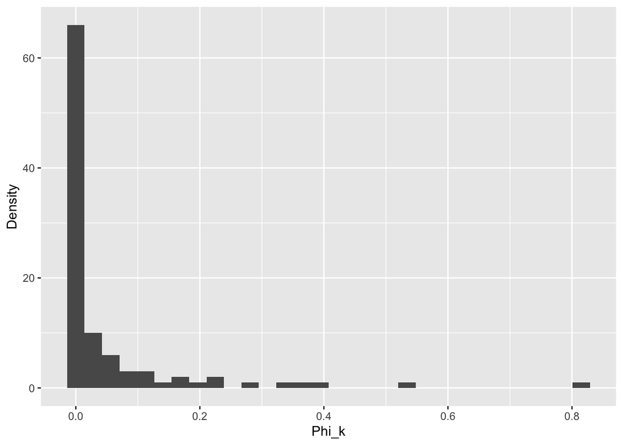

```r
ggplot(data = melt(phi),aes(x=value))+geom_histogram()+labs(x="Phi_k",y="Density")
```

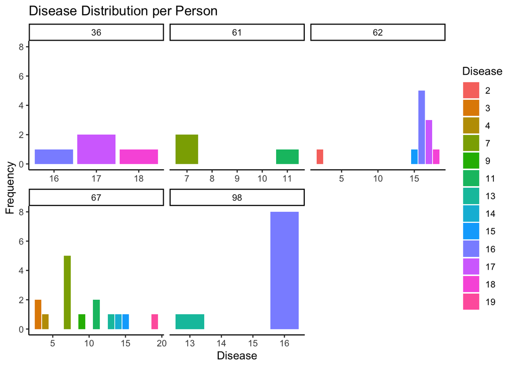

```r
# Assuming 'disease' is your list of words for each person
# Convert 'disease' list into a data frame for plotting
disease_data <- data.frame(person = rep(seq_along(disease), sapply(disease, length)),
                        disease = unlist(disease))

# Now create the plot
random_peeps=sample(M,size = 5)
ggplot(disease_data[disease_data$person%in%random_peeps,], aes(x = disease,fill=as.factor(disease))) +
  geom_bar() +
  facet_wrap(~ person, scales = "free_x") +
  theme(axis.text.x = element_text(angle = 45, hjust = 1)) +
  labs(x = "Disease", y = "Frequency", title = "Disease Distribution per Person",fill="Disease")+theme_classic()
```

## Adding a time element

Now, in McVean et al, instead of having only one phi_k per topic, there are phi_kt for a time and topic specific diagnosis distribution.

Easy enough! Recall before we had a matrix that was KxV for the disease distribtuion per topic.

Now we will initialize an *array* that is KxVxT that has a disease distribution per topic per time.

```r
K <- length(alpha)  # Number of topics
V <- length(beta)   # Number of diagnoses
T <- 10             # Number of time points
time_points <- seq(0, 1, length.out = T)
phi <- array(dim = c(K, V, T))

# Generate the spline for each topic and diagnosis
for (k in 1:K) {
  for (v in 1:V) {
    # Generate coefficients for the spline - should be of length 5

    # Generate a B-spline basis
    knots <- c(0.5) # Example knot
    degree=1
    bspline_basis <- bs(time_points, knots = knots, degree = degree, intercept = TRUE)
    coef <- runif(length(knots)+degree+1) # Adjust based on the number of columns in the bspline_basis

    # Calculate the spline values
    spline_values <- bspline_basis %*% coef

    # Store the values in the phi array
    phi[k, v, ] <- spline_values
  }
}

# Normalize probabilities in phi
phi <- apply(phi, c(1, 3), function(x) {
  x <- pmax(x, 0) # Ensure non-negative
  x / sum(x)      # Normalize
})

dim(phi)
```

```
## [1] 20  5 10
```

Now $\phi$ is the array of diseases x topics x time, so for a given topic, this should be continous. Let’s look at a sample topic with a few diseases to check:

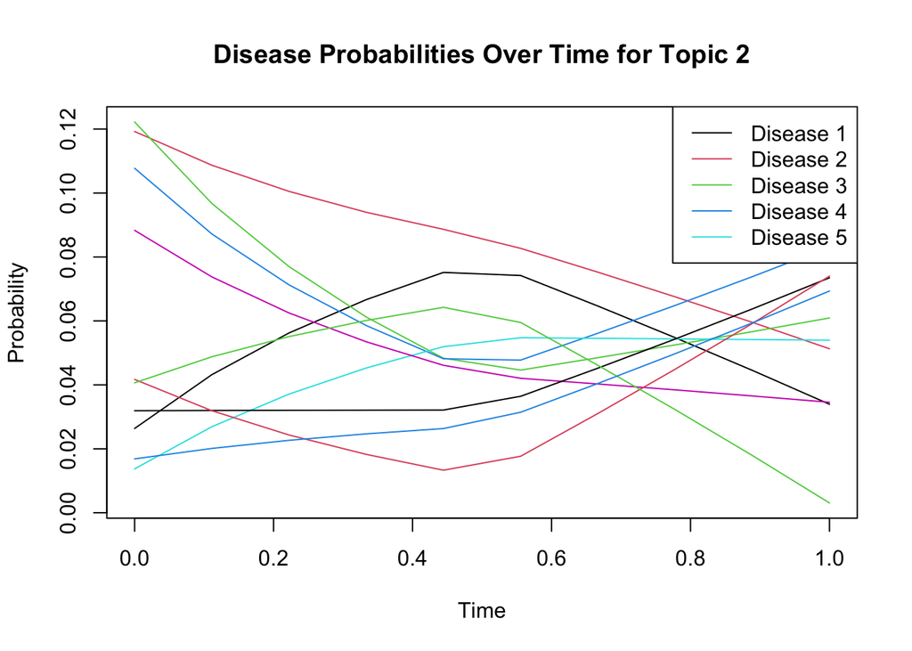

```r
# Assuming phi is already created and is a KxVxT array
# Choose a topic to plot, for example, the first topic
selected_topic <- 2
selected_diseases=sample(V,size = 10)

# Extract the data for this topic
topic_data <- phi[c(selected_diseases),selected_topic, ]

# Create a sequence of time points for the x-axis
time_points <- seq(0, 1, length.out = dim(phi)[3])

# Plotting
matplot(time_points, t(topic_data), type = 'l', lty = 1,
        xlab = "Time", ylab = "Probability",
        main = paste("Disease Probabilities Over Time for Topic", selected_topic))
legend("topright", legend = paste("Disease", 1:dim(phi)[2]), col = 1:dim(phi)[2], lty = 1)
```

## However this assumes that an individaul stays within a topic -

- that the change in disease distribtuion for a given topic captures all the heterogeneity of disease coding